# Random Forest based on Tidymodels

Machine Learning

R code using Tidymodels Package for Random Forest

Yeongeun Jeon , Jung In Seo  
04-10-2022

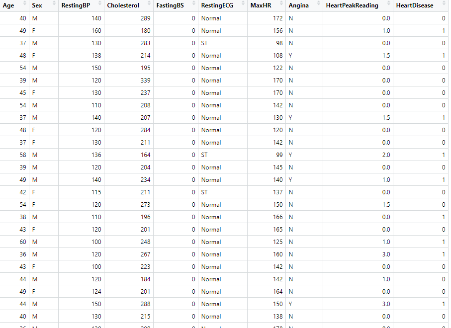

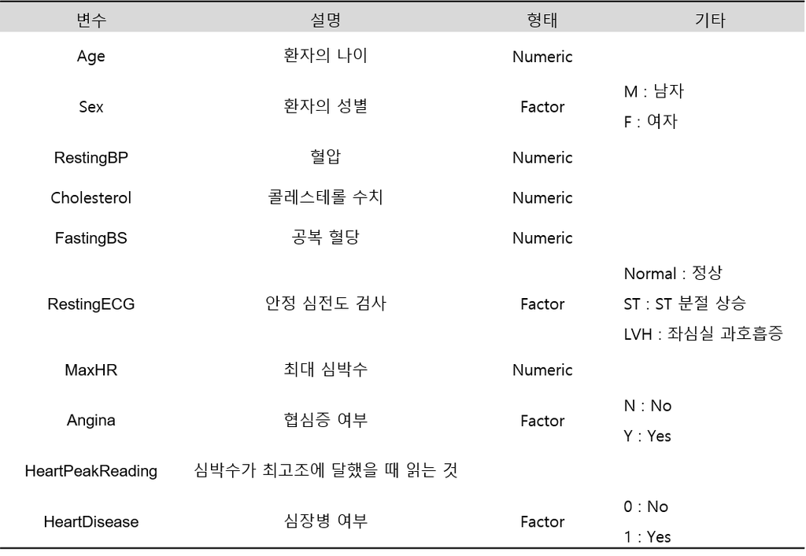

# **0. Schematic Diagram**

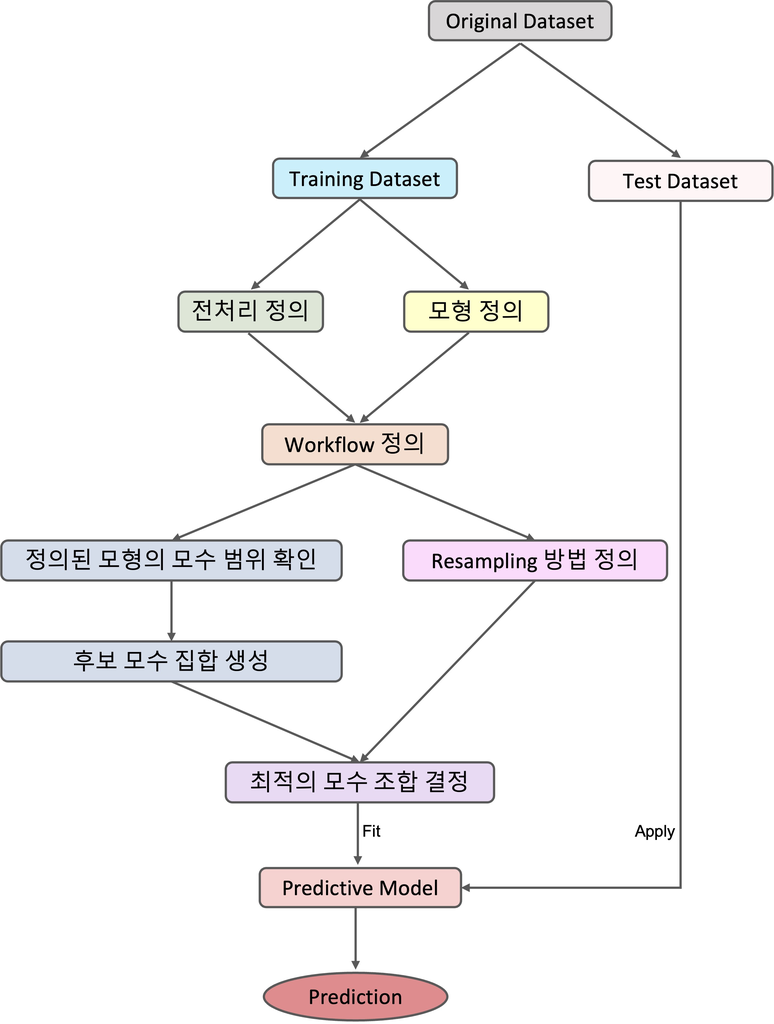

# **1. 데이터 불러오기**

```
# install.packages("tidymodels")
pacman::p_load("MLDataR",                                              # For Data
               "data.table", "magrittr",
               "tidymodels",
               "doParallel", "parallel")

registerDoParallel(cores=detectCores())


data(heartdisease)
data <- heartdisease %>%
  mutate(HeartDisease = ifelse(HeartDisease==0, "no", "yes"))


cols <- c("Sex", "RestingECG", "Angina", "HeartDisease")

data   <- data %>%
  mutate_at(cols, as.factor)                                           # 범주형 변수 변환

glimpse(data)                                                          # 데이터 구조
```

```
Rows: 918
Columns: 10
$ Age              <dbl> 40, 49, 37, 48, 54, 39, 45, 54, 37, 48, 37,~
$ Sex              <fct> M, F, M, F, M, M, F, M, M, F, F, M, M, M, F~
$ RestingBP        <dbl> 140, 160, 130, 138, 150, 120, 130, 110, 140~
$ Cholesterol      <dbl> 289, 180, 283, 214, 195, 339, 237, 208, 207~
$ FastingBS        <dbl> 0, 0, 0, 0, 0, 0, 0, 0, 0, 0, 0, 0, 0, 0, 0~
$ RestingECG       <fct> Normal, Normal, ST, Normal, Normal, Normal,~
$ MaxHR            <dbl> 172, 156, 98, 108, 122, 170, 170, 142, 130,~
$ Angina           <fct> N, N, N, Y, N, N, N, N, Y, N, N, Y, N, Y, N~
$ HeartPeakReading <dbl> 0.0, 1.0, 0.0, 1.5, 0.0, 0.0, 0.0, 0.0, 1.5~
$ HeartDisease     <fct> no, yes, no, yes, no, no, no, no, yes, no, ~
```

# **2. 데이터 분할**

[output not shown]

# **3. Random Forest**

## **3-1. 전처리 정의**

- `Workflow`를 이용하기 위해 먼저 전처리를 정의한다.

[output not shown]

## **3-2. 모형 정의**

- 모형을 구축하기 위해 모형을 먼저 정의한다.
  - 모형을 정의하기 위해 `모형 타입(Type)`과 `모형 종류(set_mode)` 그리고 `사용할 패키지(set_engine)`가 필요하다.
    - 모형 타입 : 사용하고자하는 머신러닝 함수 정의
      - Random Forest는 함수 `rand_forest()`를 사용한다.
    - 모형 종류 : Target 유형 정의
      - 분류(Classification) 또는 회귀(Regresssion) 중 하나를 선택한다.
    - 사용할 패키지 : 사용하고자하는 Package 정의
      - Random Forest는 Package `randomForest`, `ranger`, `spark`를 사용할 수 있다.
- Random Forest의 모수에는 `mtry`, `trees`, `min_n`이 있다.
  - `mtry` : 노드를 분할할 때 랜덤하게 선택되는 후보 예측변수 개수
  - `trees` : 생성하고자 하는 트리의 개수
  - `min_n` : 터미널 노드(Terminal Node)의 최소 개수
- 튜닝하고 싶은 모수는 함수 `tune()`으로 지정한다.

[output not shown]

```
Random Forest Model Specification (classification)

Main Arguments:
  mtry = tune()
  trees = tune()
  min_n = tune()

Engine-Specific Arguments:
  importance = TRUE

Computational engine: randomForest

Model fit template:
randomForest::randomForest(x = missing_arg(), y = missing_arg(),
    mtry = min_cols(~tune(), x), ntree = tune(), nodesize = min_rows(~tune(),
        x), importance = TRUE)
```

`Caution!` 함수 `translate()`를 통해 위에서 정의한 “rf.tune.mod”가 실제로 Package `randomForest`의 함수 `randomForest()`에 어떻게 적용되는지 확인할 수 있다.

## **3-3. Workflow 정의**

- 앞에서 정의한 전처리와 모형을 이용하여 `Workflow`를 정의한다.

[output not shown]

## **3-4. 모수 범위 확인**

- 함수 `extract_parameter_set_dials()`를 이용하여 모수들의 정보를 확인할 수 있다.

```
rf.param <- extract_parameter_set_dials(rf.tune.wflow)
rf.param
```

```
Collection of 3 parameters for tuning

 identifier  type    object
       mtry  mtry nparam[?]
      trees trees nparam[+]
      min_n min_n nparam[+]

Model parameters needing finalization:
   # Randomly Selected Predictors ('mtry')

See `?dials::finalize` or `?dials::update.parameters` for more information.
```

`Result!` `object`열에서 `nparam`은 모수값이 수치형임을 의미한다. 또한, `nparam[+]`는 해당 모수의 범위가 명확하게 주어졌음을 의미하고, `nparam[?]`는 모수의 범위에서 상한 또는 하한의 값이 명확하지 않다는 것을 의미한다. 이러한 경우, 상한 또는 하한의 값을 명확하게 결정하여야 한다.

- 함수 `extract_parameter_dials()`를 이용하여 모수의 범위를 자세히 확인할 수 있다.

```
rf.param %>%
  extract_parameter_dials("mtry")
```

```
# Randomly Selected Predictors (quantitative)
Range: [1, ?]
```

`Result!` `mtry`의 상한이 `?`이므로 상한값을 결정하여야 한다.

- 함수 `update()`를 이용하여 직접 범위를 지정할 수 있다.

[output not shown]

```
# Randomly Selected Predictors (quantitative)
Range: [1, 13]
```

`Result!` `mtry`의 상한이 `13`으로 수정되었다.

## **3-5. 모형 적합**

### **3-5-1. Resampling 정의**

- Random Forest의 최적의 모수 조합을 찾기 위해 Resampling 방법으로 `K-Fold Cross-Validation`을 사용한다.

```
set.seed(100)
train.fold    <- vfold_cv(HD.train, v = 5)
```

### **3-5-2. 최적의 모수 조합 찾기**

- 최적의 모수 조합을 찾기 위해 `Regular Grid`, `Latin Hypercube`, `Expand Grid`를 사용한다.

#### **3-5-2-1. Regular Grid**

```
set.seed(100)
grid <-  rf.param %>%
  grid_regular(levels = 2)
grid
```

```
# A tibble: 8 x 3
   mtry trees min_n
  <int> <int> <int>
1     1     1     2
2    13     1     2
3     1  2000     2
4    13  2000     2
5     1     1    40
6    13     1    40
7     1  2000    40
8    13  2000    40
```

`Result!` 각 모수별로 2개씩 후보값을 두어 총 8(2 $\times$ 2 $\times$ 2)개의 후보 모수 조합을 생성하였다.

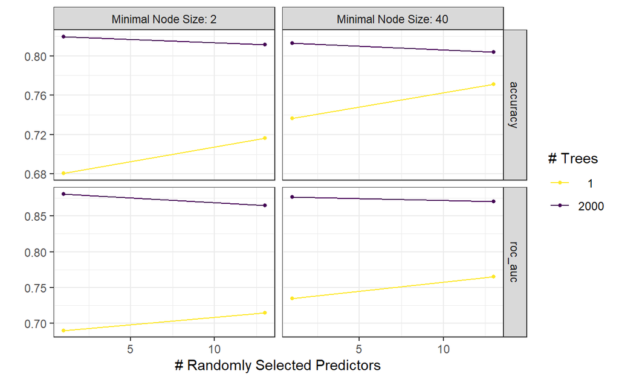

[output not shown]

[output not shown]

```
# A tibble: 5 x 9
   mtry trees min_n .metric .estimator  mean     n std_err .config
  <int> <int> <int> <chr>   <chr>      <dbl> <int>   <dbl> <fct>
1     1  2000     2 roc_auc binary     0.880     5 0.00963 Preprocess~
2     1  2000    40 roc_auc binary     0.876     5 0.00943 Preprocess~
3    13  2000    40 roc_auc binary     0.870     5 0.00517 Preprocess~
4    13  2000     2 roc_auc binary     0.864     5 0.00434 Preprocess~
5    13     1    40 roc_auc binary     0.765     5 0.0137  Preprocess~
```

[output not shown]

```
# A tibble: 1 x 4
   mtry trees min_n .config
  <int> <int> <int> <fct>
1     1  2000     2 Preprocessor1_Model3
```

`Result!` `mtry = 1`, `trees = 2000`, `min_n = 2`일 때 “ROC AUC” 측면에서 가장 우수한 성능을 보여준다.

#### **3-5-2-2. Latin Hypercube**

```
set.seed(100)
random <- rf.param %>%
  grid_latin_hypercube(size = 10)
random
```

```
# A tibble: 10 x 3
    mtry trees min_n
   <int> <int> <int>
 1     8  1762    22
 2    12   392    33
 3    10  1810    14
 4    13  1372     9
 5     1  1133    36
 6     4   733    25
 7     2    82    17
 8     5   551     5
 9     7   883    13
10     7  1537    30
```

`Result!` 10개의 후보 모수 조합을 랜덤하게 생성하였다.

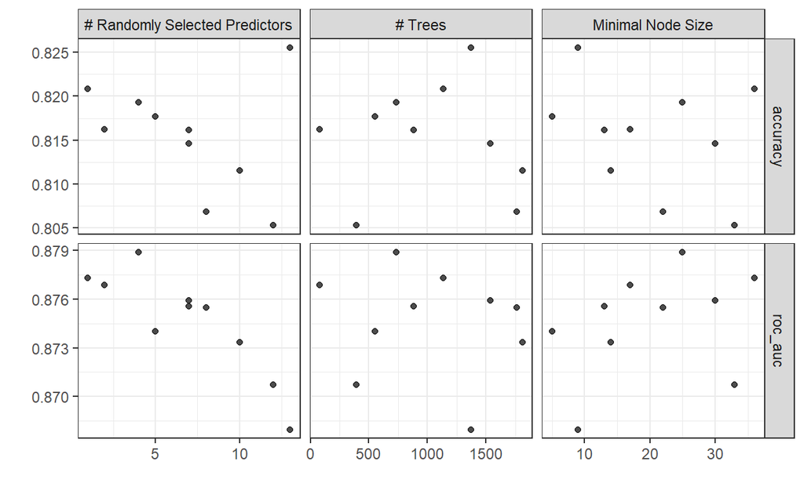

[output not shown]

[output not shown]

```
# A tibble: 5 x 9
   mtry trees min_n .metric .estimator  mean     n std_err .config
  <int> <int> <int> <chr>   <chr>      <dbl> <int>   <dbl> <fct>
1     4   733    25 roc_auc binary     0.879     5 0.00795 Preprocess~
2     1  1133    36 roc_auc binary     0.877     5 0.00991 Preprocess~
3     2    82    17 roc_auc binary     0.877     5 0.00950 Preprocess~
4     7  1537    30 roc_auc binary     0.876     5 0.00585 Preprocess~
5     7   883    13 roc_auc binary     0.876     5 0.00579 Preprocess~
```

[output not shown]

```
# A tibble: 1 x 4
   mtry trees min_n .config
  <int> <int> <int> <fct>
1     4   733    25 Preprocessor1_Model06
```

`Result!` `mtry = 4`, `trees = 733`, `min_n = 25`일 때 “ROC AUC” 측면에서 가장 우수한 성능을 보여준다.

#### **3-5-2-3. Expand Grid**

- Latin Hypercube 방법에서 최적의 모수 조합인 `mtry = 4`, `trees = 733`, `min_n = 25`를 기준으로 다양한 후보값을 생성한다.

```
egrid <- expand.grid(mtry  = 3:4,
                     trees = 732:733,
                     min_n = 24:25)

egrid
```

```
  mtry trees min_n
1    3   732    24
2    4   732    24
3    3   733    24
4    4   733    24
5    3   732    25
6    4   732    25
7    3   733    25
8    4   733    25
```

`Result!` 후보 모수값들의 집합이 생성되었다.

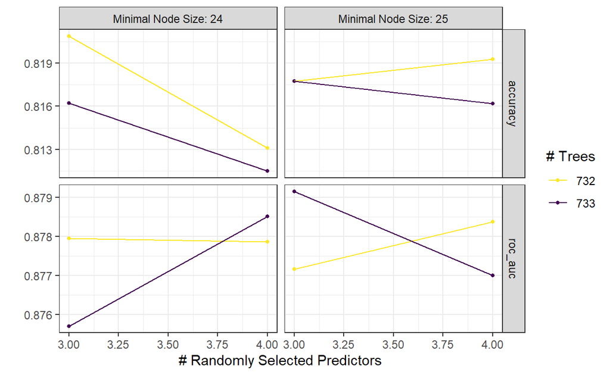

[output not shown]

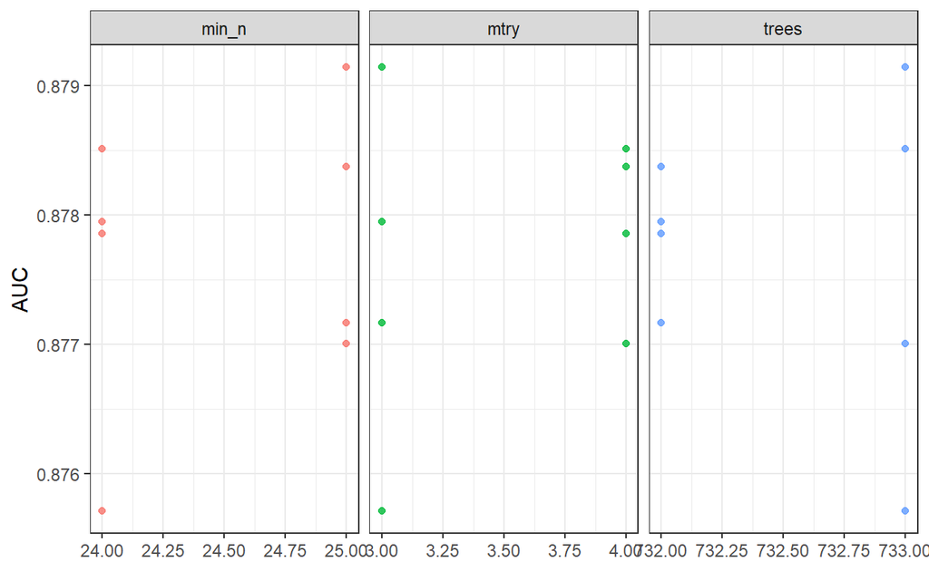

```
# Ref. https://juliasilge.com/blog/svm.lioost-tune-volleyball/
rf.tune.egrid.fit %>%
  collect_metrics() %>%
  filter(.metric == "roc_auc") %>%
  select(mean, mtry:min_n) %>%
  pivot_longer(mtry:min_n,
               values_to = "value",
               names_to = "parameter"
  ) %>%
  ggplot(aes(value, mean, color = parameter)) +
  geom_point(alpha = 0.8, show.legend = FALSE) +
  facet_wrap(~parameter, scales = "free_x") +
  labs(x = NULL, y = "AUC") +
  theme_bw()
```

[output not shown]

```
# A tibble: 5 x 9
   mtry trees min_n .metric .estimator  mean     n std_err .config
  <int> <int> <int> <chr>   <chr>      <dbl> <int>   <dbl> <fct>
1     3   733    25 roc_auc binary     0.879     5 0.00825 Preprocess~
2     4   733    24 roc_auc binary     0.879     5 0.00811 Preprocess~
3     4   732    25 roc_auc binary     0.878     5 0.00820 Preprocess~
4     3   732    24 roc_auc binary     0.878     5 0.00790 Preprocess~
5     4   732    24 roc_auc binary     0.878     5 0.00763 Preprocess~
```

[output not shown]

```
# A tibble: 1 x 4
   mtry trees min_n .config
  <int> <int> <int> <fct>
1     3   733    25 Preprocessor1_Model7
```

`Result!` `mtry = 3`, `trees = 733`, `min_n = 25`일 때 “ROC AUC” 측면에서 가장 우수한 성능을 보여준다.

### **3-5-3. 최적의 모수 조합을 이용한 모형 적합**

- 최적의 모수 조합 `mtry = 3`, `trees = 733`, `min_n = 25`를 이용하여 모형을 구축한다.
- 함수 `finalize_workflow()`을 이용하여 앞에서 정의한 “workflow(rf.tune.wflow)”를 최적의 모수 조합을 가지는 “workflow”로 업데이트한다.

[output not shown]

```
== Workflow ==========================================================
Preprocessor: Recipe
Model: rand_forest()

-- Preprocessor ------------------------------------------------------
2 Recipe Steps

* step_normalize()
* step_dummy()

-- Model -------------------------------------------------------------
Random Forest Model Specification (classification)

Main Arguments:
  mtry = 3
  trees = 733
  min_n = 25

Engine-Specific Arguments:
  importance = TRUE

Computational engine: randomForest
```

`Caution!` 함수 `last_fit()`은 최적의 모수 조합에 대해 Training Data를 이용한 모형 적합과 Test Data에 대한 예측을 한 번에 수행할 수 있지만 seed 고정이 되지 않아 Reproducibility (재생산성)가 만족되지 않는다. 따라서, 모형 적합(함수 `fit()`)과 예측(함수 `augment()`)을 각각 수행하였다.

[output not shown]

```
== Workflow [trained] ================================================
Preprocessor: Recipe
Model: rand_forest()

-- Preprocessor ------------------------------------------------------
2 Recipe Steps

* step_normalize()
* step_dummy()

-- Model -------------------------------------------------------------

Call:
 randomForest(x = maybe_data_frame(x), y = y, ntree = ~733L, mtry = min_cols(~3L,      x), nodesize = min_rows(~25L, x), importance = ~TRUE)
               Type of random forest: classification
                     Number of trees: 733
No. of variables tried at each split: 3

        OOB estimate of  error rate: 18.38%
Confusion matrix:
     no yes class.error
no  224  63   0.2195122
yes  55 300   0.1549296
```

[output not shown]

```
Call:
 randomForest(x = maybe_data_frame(x), y = y, ntree = ~733L, mtry = min_cols(~3L,      x), nodesize = min_rows(~25L, x), importance = ~TRUE)
               Type of random forest: classification
                     Number of trees: 733
No. of variables tried at each split: 3

        OOB estimate of  error rate: 18.38%
Confusion matrix:
     no yes class.error
no  224  63   0.2195122
yes  55 300   0.1549296
```

#### **3-5-3-1. 변수 중요도**

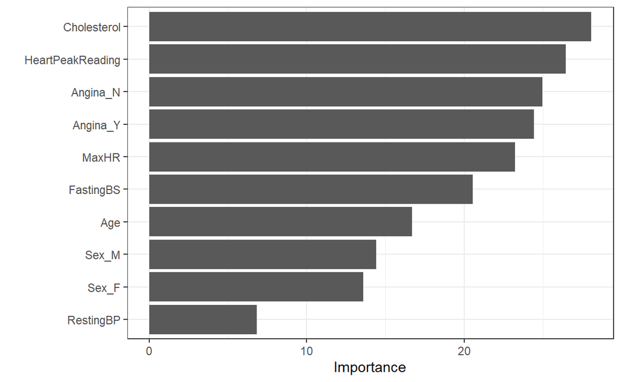

```
final.fit %>%
  vip::vip() +
  theme_bw()
```

#### **3-5-3-2. OBB Error**

```
# OBB Error
head(final.fit$err.rate)
```

```
           OOB        no       yes
[1,] 0.2580645 0.2480000 0.2682927
[2,] 0.2386935 0.2656250 0.2135922
[3,] 0.2301255 0.2266667 0.2332016
[4,] 0.2384473 0.2419355 0.2354949
[5,] 0.2293103 0.2461538 0.2156250
[6,] 0.2211055 0.2518797 0.1963746
```

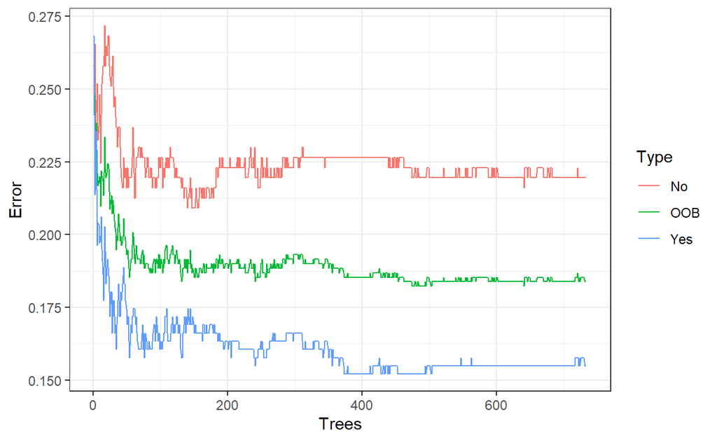

```
# Plot for Error
pacman::p_load("ggplot2")

oob.error.data <- data.frame(Trees=rep(1:nrow(final.fit$err.rate),times=3),
                             Type=rep(c("OOB","No","Yes"),
                                      each=nrow(final.fit$err.rate)),
                             Error=c(final.fit$err.rate[,"OOB"],
                                     final.fit$err.rate[,"no"],
                                     final.fit$err.rate[,"yes"]))


ggplot(data=oob.error.data, aes(x=Trees, y=Error)) +
  geom_line(aes(color=Type)) + theme_bw()
```

## **3-6. 예측**

```
rf.pred <- augment(final.rf, HD.test)
rf.pred
```

```
# A tibble: 276 x 13
     Age Sex   RestingBP Cholesterol FastingBS RestingECG MaxHR Angina
   <dbl> <fct>     <dbl>       <dbl>     <dbl> <fct>      <dbl> <fct>
 1    54 M           110         208         0 Normal       142 N
 2    37 M           140         207         0 Normal       130 Y
 3    37 F           130         211         0 Normal       142 N
 4    39 M           120         204         0 Normal       145 N
 5    49 M           140         234         0 Normal       140 Y
 6    42 F           115         211         0 ST           137 N
 7    60 M           100         248         0 Normal       125 N
 8    36 M           120         267         0 Normal       160 N
 9    43 F           100         223         0 Normal       142 N
10    36 M           130         209         0 Normal       178 N
# ... with 266 more rows, and 5 more variables:
#   HeartPeakReading <dbl>, HeartDisease <fct>, .pred_class <fct>,
#   .pred_no <dbl>, .pred_yes <dbl>
```

## **3-7. 모형 평가**

### **3-7-1. 평가 척도**

```
conf_mat(rf.pred, truth = HeartDisease, estimate = .pred_class)        # truth : 실제 클래스,  estimate : 예측 클래스 클래스
```

```
          Truth
Prediction  no yes
       no   95  26
       yes  28 127
```

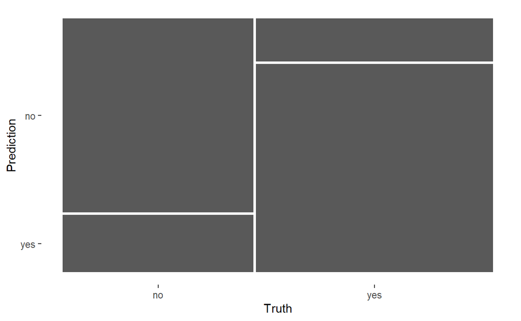

```
conf_mat(rf.pred, truth = HeartDisease, estimate = .pred_class) %>%
  autoplot(type = "mosaic")                                            # autoplot(type = "heatmap")
```

```
classification_metrics <- metric_set(accuracy, mcc,
                                     f_meas, kap,
                                     sens, spec, roc_auc)              # Test Data에 대한 Assessment Measure
classification_metrics(rf.pred, truth = HeartDisease,                  # truth : 실제 클래스,  estimate : 예측 클래스 클래스
                       estimate = .pred_class,
                       .pred_yes, event_level = "second")              # For roc_auc
```

```
# A tibble: 7 x 3
  .metric  .estimator .estimate
  <chr>    <chr>          <dbl>
1 accuracy binary         0.804
2 mcc      binary         0.603
3 f_meas   binary         0.825
4 kap      binary         0.603
5 sens     binary         0.830
6 spec     binary         0.772
7 roc_auc  binary         0.883
```

`Caution!` “ROC AUC”를 계산하기 위해서는 관심 클래스에 대한 예측 확률이 필요하다. 예제 데이터에서 관심 클래스는 “yes”이므로 “yes”에 대한 예측 확률 결과인 `.pred_yes`가 사용되었다. 또한, Target인 “HeartDisease” 변수의 유형을 “Factor” 변환하면 알파벳순으로 클래스를 부여하기 때문에 관심 클래스 “yes”가 두 번째 클래스가 된다. 따라서 옵션 `event_level = "second"`을 사용하여 관심 클래스가 “yes”임을 명시해주어야 한다.

### **3-7-2. 그래프**

`Caution!` 함수 “roc_curve(), gain_curve(), lift_curve(), pr_curve()”에서는 첫번째 클래스(Level)를 관심 클래스로 인식한다. R에서는 함수 `Factor()`를 이용하여 변수 유형을 변환하면 알파벳순(영어) 또는 오름차순(숫자)으로 클래스를 부여하므로 “HeartDisease” 변수의 경우 “no”가 첫번째 클래스가 되고 “yes”가 두번째 클래스가 된다. 따라서, 예제 데이터에서 관심 클래스는 “yes”이기 때문에 옵션 `event_level = "second"`을 사용하여 관심 클래스가 “yes”임을 명시해주어야 한다.

#### **3-7-2-1. ROC Curve**

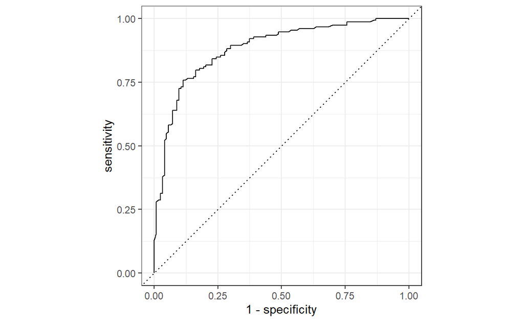

```
rf.pred %>%
  roc_curve(truth = HeartDisease, .pred_yes,                           # truth : 실제 클래스,  관심 클래스 예측 확률  확률
            event_level = "second") %>%
  autoplot()
```

#### **3-7-2-2. Gain Curve**

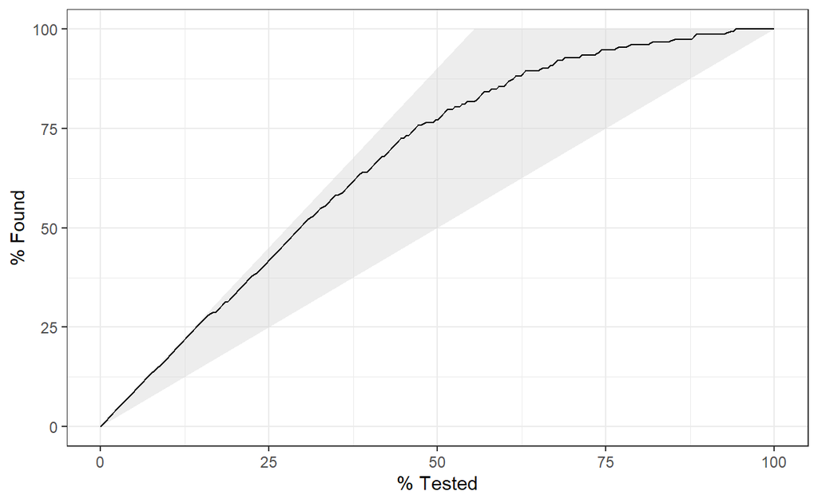

```
rf.pred %>%
  gain_curve(truth = HeartDisease, .pred_yes,                          # truth : 실제 클래스,  관심 클래스 예측 확률  확률
             event_level = "second") %>%
  autoplot()
```

#### **3-7-2-3. Lift Curve**

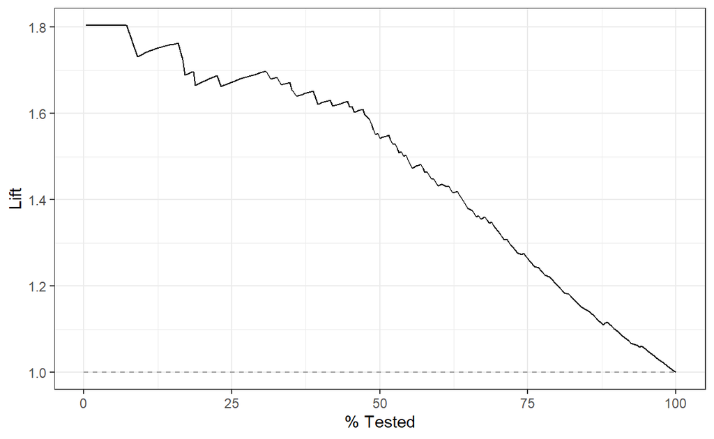

```
rf.pred %>%
  lift_curve(truth = HeartDisease, .pred_yes,                          # truth : 실제 클래스,  관심 클래스 예측 확률측 확률
             event_level = "second") %>%
  autoplot()
```

#### **3-7-2-4. Precision Recall Curve**

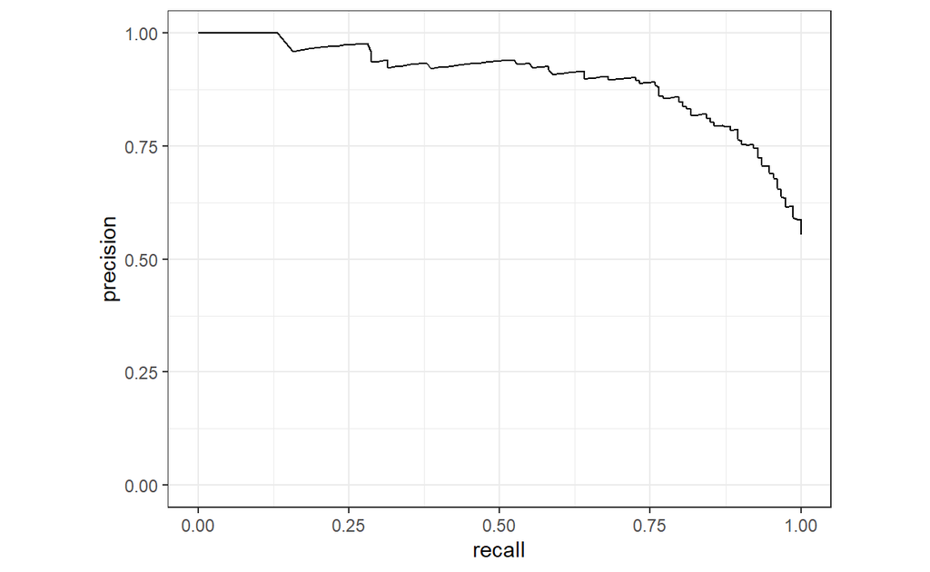

```
rf.pred %>%
  pr_curve(truth = HeartDisease, .pred_yes,                            # truth : 실제 클래스,  관심 클래스 예측 확률  확률
           event_level = "second") %>%
  autoplot()
```